# Arbeidskrav 4

Mari Hårstad Meslo

$~$

## Del 1

### Bakgrunn

Bakgrunnen for del 1 i denne oppgaven er å se hva som er den anbefalte intensiteten for å utvikle styrke, altså for å øke 1RM. Dataene i datasettet ser på forskjellen mellom trening med 10RM og 30RM.

*Hypotese*: 10RM-gruppa har større økning i 1RM enn 30RM-gruppa.

$~$

### Metode

#### Studiedesign

Denne studien er en randomisert studie utført med to eksperimentelle grupper som undersøkte om effekten av trening med 10RM eller 30RM øker 1RM. Skriftlig informert samtykke ble innhentet fra alle deltakerne.

$~$

#### Forsøkspersoner

Forsøkspersonene i denne studien bestod av 31 kvinner i alderen 30-45 år, hvor alle var tidligere styrkeløftere som har konkurrert på internasjonalt nivå. Forsøkspersonene ble randomisert i to grupper; den ene gruppa trente 3 sett x 10 repetisjoner maksimum (RM), den andre gruppa trente 3 sett x 30RM. Av de 31 forsøkspersonene som deltok ved oppstart av studien, var det 24 deltakere som fullførte hele treningsintervensjonen.

$~$

#### Trening og testing

Treningsintervensjonen varte i 10 uker, med pretest i forkant, hvor 1RM i beinpress, bicepscurl og benkpress ble testet. Forsøkspersonene trente et helkroppsprogram, med 3 økter per uke, og intensitet etter hvilken gruppe de tilhørte (3x10RM/3x30RM). Etter 5 uker ble det uført en mid-test, og etter fullført intervensjonsperiode ble det utført en posttest hvor de samme øvelsene i pretest ble testet. I denne statistiske rapporten vil vi kun se på dataen fra legpress-testene.

$~$

#### Dataanalyse

De statistiske dataene ble analysert med R og R-studio, og signifikansnivået ble satt til p<0.05. Dataen ble brukt til å lage en mixed model. Mixed model ble brukt på grunn av at studien var randomisert, og denne modellen sammenligner dataen til hver forsøksperson fra sitt utgangspunkt (intercept). Mixed model sammenligner de to gruppene (RM30 og RM10) og estimerer økning av motstand (kg) over de tre testtidspunktene. Videre ble dataen fra mixed model brukt til å fremstille forskjellene mellom gruppene grafisk.

$~$

### Resultater

Resultatene i tabell 1 viser gjennomsnittlige estimater for de to ulike gruppene ved de tre testtidspunktene. Estimatet for *(Intercept)* i tabellen representerer det gjennomsnittlige resultatet ved pretest for 30RM-gruppa (281,5 kg). Estimatet for *timepointmid* viser hvor mye 30RM-gruppa har økt fra pre- til midtest (35,0 kg), mens *timepointpost* viser hvor mye gruppa har økt fra pre- til posttest (38,9 kg). Estimatet for *groupRM10* viser forskjellen mellom 10RM-gruppa og 30RM-gruppa ved pretest (-7,6 kg). *timepointmid;groupRM10* viser hvor mye 10RM-gruppa har økt i forhold til 30RM-gruppa fra pre- til midtest (11,1 kg), og *timepointpost:groupRM10* viser hvor mye gruppa har økt i forhold til 30RM-gruppa fra pre- til posttest (38,6 kg).

Konfidensintervallet for variabelen *timepointpost:groupRM10* viser at det er en signifikant økning i styrke mellom 10RM-gruppa og 30RM-gruppa fra pre- til posttest, med 95% konfidensintervall [13,57 - 63,59].

Resultatene fra tabell 1 er fremstilt grafisk i figur 1. Den øverste delen av figuren viser gjennomsnittlig endring, samt konfidensintervall, i de to gruppene ved de tre ulike testtidspunktene. Den nederste delen av figuren viser den gjennomsnittlige forskjellen i gruppene ved mid- og posttest.

$~$ $~$

**Tabell 1**

|  | Estimate | Std. error | DF | T-verdi | P-verdi | CI 2,5% | CI 95% |
| --- | --- | --- | --- | --- | --- | --- | --- |
| (Intercept) | 281.5 | 20.12 | 29 | 13.99 | 0.0000 | 242.37 | 320.70 |
| timepointmid | 35.0 | 8.97 | 47 | 3.90 | 0.0003 | 17.80 | 52.20 |
| timepointpost | 38.9 | 9.55 | 47 | 4.07 | 0.0002 | 20.54 | 57.16 |
| groupRM10 | -7.6 | 27.94 | 29 | -0.27 | 0.7873 | -62.00 | 46.78 |
| timepointmid:groupRM10 | 11.1 | 12.45 | 47 | 0.89 | 0.3786 | -12.81 | 34.95 |
| timepointpost:groupRM10 | 38.6 | 13.04 | 47 | 2.96 | 0.0048 | 13.57 | 63.59 |

$~$

$~$

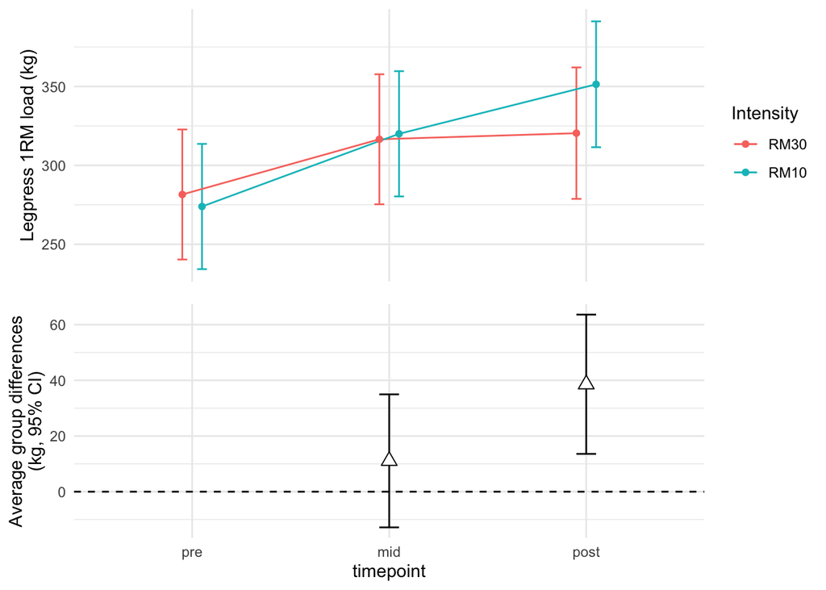

**Figur 1**

$~$

$~$

### Diskusjon

Formålet med denne studien var å se på effekten av ulik treningsintensitet med formål om å øke muskelstyrke i 1RM i øvelsen beinpress. Studien sammenlignet en treningsgruppe som trente på 30RM med en som trente på 10RM.

Resultatene viste at 10RM gruppa hadde en signifikant økning sammenlignet med 30RM-gruppa fra pre- til posttest. Dette vises ved at konfidensintervallet for variabelen *timepointpost:groupRM10* strekker seg fra [13,57 - 63,59], og ikke inneholder 0.

Forskning viser at for å øke styrke og hypertrofi hos voksne er det anbefalt å trene med 1-3 sett per øvelse, 8-12 repetisjoner med 60-80% av 1RM (“Progression Models in Resistance Training for Healthy Adults” 2009). Dette samsvarer med funnene i vår studie, som viser at trening med 3 sett x 10RM gir større økning i muskelstyrke ved 1RM enn trening med 3 sett x 30RM. En annen studie viser imidlertid at det optimale antallet repetisjoner for å raskest mulig øke styrken er 3-9 (Berger 1962). Dette kan vise at et lavt antall repetisjoner er mest gunstig for å øke 1RM.

$~$

## Del 2

### Bakgrunn

Bakgrunnen for del 2 i denne oppgaven er å se hva som er anbefalt treningsvolum for å utvikle styrke. Studien ser på forskjellen mellom å trene med ett sett (single) eller å trene med tre sett (multiple).

Hypotese: Multiple-gruppa har større økning i muskelstyrke sammenlignet med single-gruppa.

### Metode

#### Studiedesign

Denne studien er en randomisert studie utført med to eksperimentelle grupper som undersøkte om effekten av trening med ett eller tre sett øker muskelstyrke. Skriftlig informert samtykke ble innhentet fra alle deltakerne.

$~$

#### Forsøkspersoner

Forsøkspersonene i denne studien bestod av 34 personer (16 menn og 18 kvinner) i alderen 20-29 år, hvor alle er aktive ballettdansere på Nationaltheateret. Alle deltakerne fullførte hele treningsintervensjonen. Forsøkspersonene ble randomisert i to grupper; den ene gruppa trente 1 sett x 8 repetisjoner maksimum (RM), den andre gruppa trente 3 sett x 8RM.

$~$

#### Trening og testing

Treningsintervensjonen varte i 6 uker, med pretest i forkant, en test etter første treningsøkt, og en posttest etter endt intervensjon.

$~$

#### Dataanalyse

De statistiske dataene ble analysert med R og R-studio, og signifikansnivået ble satt til p<0.05. Dataen ble brukt til å lage en mixed model. Mixed model ble brukt på grunn av at studien var randomisert, og denne modellen sammenligner dataen til hver forsøksperson fra sitt utgangspunkt (intercept). Mixed model sammenligner de to gruppene (single og multiple) og estimerer økning av muskelkraft (Nm) over de tre testtidspunktene. Videre ble dataen fra mixed model brukt til å fremstille forskjellene mellom gruppene grafisk.

$~$

### Resultater

$~$ $~$

**Tabell 2**

|  | Estimate | Std. error | DF | t-verdi | p-verdi | CI 2,5% | CI 97,5% |
| --- | --- | --- | --- | --- | --- | --- | --- |
| (Intercept) | 215.0 | 15.75 | 36.9 | 13.65 | 0.000 | 184.3 | 245.7 |
| timepointsession1 | 2.2 | 7.20 | 63.0 | 0.30 | 0.764 | -11.7 | 16.1 |
| timepointpost | 34.4 | 7.20 | 63.0 | 4.78 | 0.000 | 20.6 | 48.3 |
| groupmultiple | -3.3 | 22.28 | 36.9 | -0.15 | 0.884 | -46.7 | 40.2 |
| timepointsession1:groupmultiple | 3.9 | 10.19 | 63.0 | 0.39 | 0.700 | -15.7 | 23.6 |
| timepointpost:groupmultiple | 20.0 | 10.30 | 63.1 | 1.94 | 0.057 | 0.1 | 39.8 |

$~$

$~$

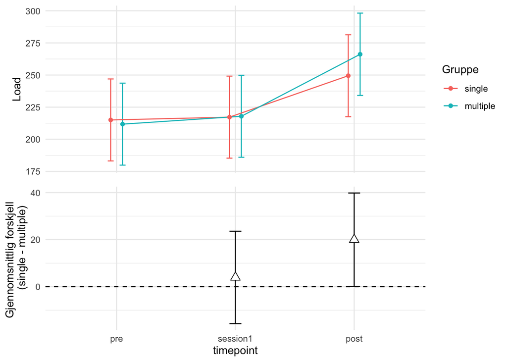

**Figur 2**

$~$ $~$

### Diskusjon

Som vi ser ut fra tabell 2 og figur 2, kan resultatene tolkes som at det er en tendens for at det kan være gunstig å trene med flere sett av en øvelse, altså høyere volum. Dette ut i fra at konfidensintervallet hos variabelen som sammenligner de to gruppene ved post-test viser [0.1- 39.8]. Figur 2 viser også at forskjellen mellom gruppene blir gradvis større, og ut fra denne tendensen kan det tenkes at effekten for multiple-gruppen ville blitt enda større ved en lengre intervensjon. I studien til Ribeiro et al. (2015) konkluderte de med at trening med 3 sett over en 12ukers treningsperiode ga signifikant økning i muskelstyrke sammenlignet med trening med kun ett sett. Dette viste også studien til Bottaro et al. (2011), som så på effekten av trening med ett vs tre sett. Resultatene viste at trening med tre sett ga signifikant økning i muskelkraft i knestrekkerne ved 60graders bøy i kneleddet sammenlignet med trening med ett sett. Dette kan forsterke vår antagelse om at effekten av trening med flere sett ville vært tydeligere ved en lengre intervensjon.

$~$ $~$

## Referanser

Berger, Richard A. 1962. “Optimum Repetitions for the Development of Strength.” *Research Quarterly. American Association for Health, Physical Education and Recreation* 33 (3): 334–38. https://doi.org/10.1080/10671188.1962.10616460.

Bottaro, M., J. Veloso, D. Wagner, and P. Gentil. 2011. “Resistance Training for Strength and Muscle Thickness: Effect of Number of Sets and Muscle Group Trained.” *Science & Sports* 26 (5): 259–64. https://doi.org/10.1016/j.scispo.2010.09.009.

“Progression Models in Resistance Training for Healthy Adults.” 2009. *Medicine & Science in Sports & Exercise* 41 (3): 687–708. https://doi.org/10.1249/mss.0b013e3181915670.

Ribeiro, Alex S., Brad J. Schoenfeld, Fábio L. C. Pina, Mariana F. Souza, Matheus A. Nascimento, Leandro dos Santos, Melissa Antunes, and Edilson S. Cyrino. 2015. “Resistance Training in Older Women: Comparison of Single Vs. Multiple Sets on Muscle Strength and Body Composition.” *Isokinetics and Exercise Science* 23 (1): 53–60. https://doi.org/10.3233/IES-140564.